# Predicting the Likelihood of Being Overweight using Machine Learning Models

Ainsley Carlson

2025-10-27

## 1 Overview of Analysis

Using data on obesity levels based on physical condition and eating habits, I aim to predict if a respondent is overweight or not based on if they have a family member that is overweight or not. To complete this prediction I will create several different models and decide which performs the best out of all the models. The models I will be using will be a logistic regression as a reference model, a single-layer neural network, a decision tree, and an ensemble trees-BAGGING. The models will be compared across mmultiple tests and criteria to determine which model performs the best.

## 2 Dataset Description

The dataset used for this analysis comes from the UC Irvine Machine Learning Repository and was donated to the site on August 26, 2019. The data contains 17 attributes and 2111 records to estimate obesity levels from eating habbits and physical condition of individuals from Mexico, Colombia, and Peru. Of the 2,111 observations, 485 of which came from users through a survey available on a web platform for 30 days. The distribution of weight categories was not evenly balanced, so the rest of the data was generated synthetically using the Weka tool and SMOTE filter.

### 2.1 Variables

Gender [Categorical]: Gender of respondent

Age [Numerical]: Age of respondent

Height [Numerical]: Height of respondent in meters

Weight [Numerical]: Weight of respondent in kilograms

family_history_with_overweight [Binary]: Has a family member suffered or suffers from overweight?

FAVC [Binary]: Do you eat high caloric food frequently?

FCVC [Integer]: Do you usually eat vegetables in your meals?

NCP [Numerical]: How many main meals do you have daily?

CAEC [Categorical]: Do you eat any food between meals?

SMOKE [Binary]: Do you smoke?

CH2O [Numerical]: How much water do you drink daily?

SCC [Binary]: Do you monitor the calories you eat daily?

FAF [Numerical]: How often do you have physical activity?

TUE [Numerical]: How much time do you use technological devices such as cell phone, videogames, television, computer and others?

CALC [Categorical]: How often do you drink alcohol?

MTRANS [Categorical]: Which transportation do you usually use?

NObeyesdad [Categorical]: Obesity level

## 3 Exploratory Data Analysis

```r
p1<-obesity %>%
  ggplot(aes(x = Gender, fill=Gender)) +
  geom_bar()  +
  labs(title="Gender of Respondents") +
  scale_x_discrete(labels=c("Female", "Male")) +
  theme_minimal() +
   theme(legend.position='none', axis.text.x = element_text(angle=0, vjust=.7, hjust=0.8))


p2<-obesity %>%
  ggplot(aes(x = Age)) +
  geom_histogram(bins=15,  fill="#F8766D", color="#F8826D") +
  labs(title="Age of Respondents", x="Age in Years", y="Count")  +
  theme_minimal() +
   theme(legend.position='none', axis.text.x = element_text(angle=0, vjust=.7, hjust=0.8))


p3<-obesity %>%
  ggplot(aes(x = Height)) +
  geom_histogram(bins=20, fill="#F8766D", color="#F8826D") +
  labs(title="Height of Respondents", x="Height in Meters", y="Count")  +
  theme_minimal() +
   theme(legend.position='none', axis.text.x = element_text(angle=0, vjust=.7, hjust=0.8))


p4<-obesity %>%
  ggplot(aes(x = Weight)) +
  geom_histogram(bins=20, fill="#00BFC4", color="#00BFD4") +
  labs(title="Weight of Respondents", x="Weight in Kilograms", y="Count")  +
  theme_minimal() +
   theme(legend.position='none', axis.text.x = element_text(angle=0, vjust=.7, hjust=0.8))
```

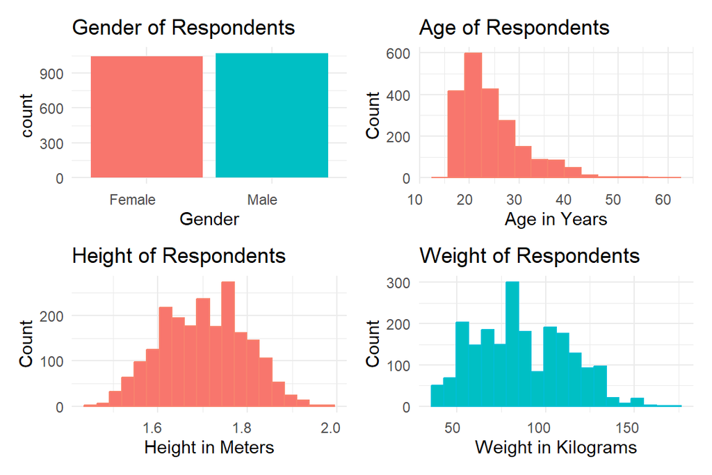

```r
p1 + p2 + p3 + p4 +
  plot_layout(ncol = 2)
```

```r
g1 <- obesity %>%
  ggplot(aes(x = FAVC, fill=FAVC)) +
  geom_bar() +
  labs(title="Do you eat high caloric food frequently?", x="", y="Count", fill="Weight Category") +
  theme_minimal() +
  scale_x_discrete(labels=c("No", "Yes")) +
   theme(legend.position='none', axis.text.x = element_text(angle=0, vjust=.7, hjust=0.8))


g2 <- obesity %>%
  ggplot(aes(x = SMOKE, fill=SMOKE)) +
  geom_bar() +
  labs(title="Do you Smoke", x="", y="Count", fill="Weight Category") +
  scale_x_discrete(labels=c("No", "Yes")) +
  theme_minimal() +
   theme(legend.position='none', axis.text.x = element_text(angle=0, vjust=.7, hjust=0.8))



g3 <- obesity %>%
  ggplot(aes(x = SCC, fill=SCC)) +
  geom_bar() +
  labs(title="Monitor the Number of Calories you Eat?", x="", y="Count", fill="Weight Category") +
  scale_x_discrete(labels=c("No", "Yes")) +
  theme_minimal() +
   theme(legend.position='none', axis.text.x = element_text(angle=0, vjust=.7, hjust=0.8))


 g4 <- obesity %>%
   mutate(CALC = fct_relevel(CALC, "no", "Sometimes", "Frequently", "Always")) %>%
  ggplot(aes(x = CALC, fill=CALC)) +
  geom_bar() +
  labs(title="How Often do you Drink Alcohol", x="Alcohol Frequenc", y="Count",) +
  theme_minimal() +
   scale_x_discrete(labels=c("Never", "Sometimes", "Frequently", "Always")) +
   theme(legend.position='none', axis.text.x = element_text(angle=0, vjust=.7, hjust=0.8))

g5 <- obesity %>%
  mutate(MTRANS = fct_relevel(MTRANS, "Walking", "Bike", "Motorbike", "Public_Transportation", "Automobile")) %>%
  ggplot(aes(x = MTRANS, fill=MTRANS)) +
  geom_bar() +
  labs(title="Transportation Typically Used", x="Mode of Transportation", y="Count") +
  theme_minimal() +
   scale_x_discrete(labels=c( "Walking", "Bike", "Motorbike", "Public Transportation", "Automobile")) +
   theme(legend.position='none', axis.text.x = element_text(angle=30, vjust=.7, hjust=0.8))



g6 <- obesity %>%
  mutate(NObeyesdad = fct_relevel(NObeyesdad, "Insufficient_Weight", "Normal_Weight", "Overweight_Level_I", "Overweight_Level_II", "Obesity_Type_I", "Obesity_Type_II", "Obesity_Type_III")) %>%
  ggplot(aes(x = NObeyesdad, fill=NObeyesdad)) +
  geom_bar() +
  labs(title="Observations by Weight Category", x="Weight Category", y="Count", fill="Weight Category") +
  theme_minimal() +
  scale_x_discrete(labels=c("Insufficient Weight", "Normal Weight", "Overweight Level 1", "Overweight Level 2", "Obesity Type 1", "Obesity Type 2", "Obesity Type 3")) +
   theme(legend.position='none', axis.text.x = element_text(angle=30, vjust=.7, hjust=0.8))
```

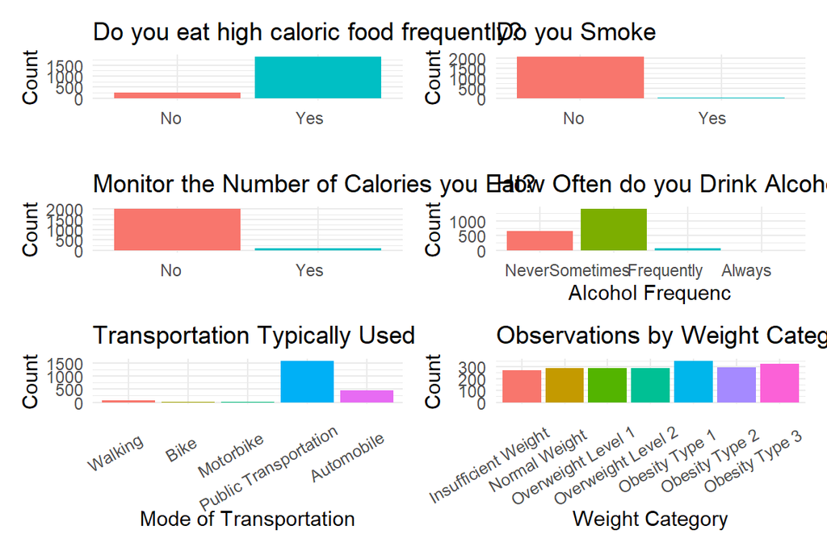

```r
g1 + g2 + g3 + g4 + g5 + g6 +
  plot_layout(ncol = 2)
```

### 3.1 Missing Variables and Feature Engineering

```r
summary(obesity)
```

```
    Gender               Age            Height          Weight
 Length:2111        Min.   :14.00   Min.   :1.450   Min.   : 39.00
 Class :character   1st Qu.:19.95   1st Qu.:1.630   1st Qu.: 65.47
 Mode  :character   Median :22.78   Median :1.700   Median : 83.00
                    Mean   :24.31   Mean   :1.702   Mean   : 86.59
                    3rd Qu.:26.00   3rd Qu.:1.768   3rd Qu.:107.43
                    Max.   :61.00   Max.   :1.980   Max.   :173.00
 family_history_with_overweight     FAVC                FCVC
 Length:2111                    Length:2111        Min.   :1.000
 Class :character               Class :character   1st Qu.:2.000
 Mode  :character               Mode  :character   Median :2.386
                                                   Mean   :2.419
                                                   3rd Qu.:3.000
                                                   Max.   :3.000
      NCP            CAEC              SMOKE                CH2O
 Min.   :1.000   Length:2111        Length:2111        Min.   :1.000
 1st Qu.:2.659   Class :character   Class :character   1st Qu.:1.585
 Median :3.000   Mode  :character   Mode  :character   Median :2.000
 Mean   :2.686                                         Mean   :2.008
 3rd Qu.:3.000                                         3rd Qu.:2.477
 Max.   :4.000                                         Max.   :3.000
     SCC                 FAF              TUE             CALC
 Length:2111        Min.   :0.0000   Min.   :0.0000   Length:2111
 Class :character   1st Qu.:0.1245   1st Qu.:0.0000   Class :character
 Mode  :character   Median :1.0000   Median :0.6253   Mode  :character
                    Mean   :1.0103   Mean   :0.6579
                    3rd Qu.:1.6667   3rd Qu.:1.0000
                    Max.   :3.0000   Max.   :2.0000
    MTRANS           NObeyesdad
 Length:2111        Length:2111
 Class :character   Class :character
 Mode  :character   Mode  :character
```

```r
unique(obesity$Gender)
```

```
[1] "Female" "Male"
```

```r
unique(obesity$family_history_with_overweight)
```

```
[1] "yes" "no"
```

```r
unique(obesity$FAVC)
```

```
[1] "no"  "yes"
```

```r
unique(obesity$CAEC)
```

```
[1] "Sometimes"  "Frequently" "Always"     "no"
```

```r
unique(obesity$SMOKE)
```

```
[1] "no"  "yes"
```

```r
unique(obesity$SCC)
```

```
[1] "no"  "yes"
```

```r
unique(obesity$CALC)
```

```
[1] "no"         "Sometimes"  "Frequently" "Always"
```

```r
unique(obesity$MTRANS)
```

```
[1] "Public_Transportation" "Walking"               "Automobile"
[4] "Motorbike"             "Bike"
```

```r
unique(obesity$NObeyesdad)
```

```
[1] "Normal_Weight"       "Overweight_Level_I"  "Overweight_Level_II"
[4] "Obesity_Type_I"      "Insufficient_Weight" "Obesity_Type_II"
[7] "Obesity_Type_III"
```

Looking at a summary of all the variable shows there are no missing values for the numerical or character variables. The ranges for the numerical variables all appear plausible and the responses for the character variables are all plausible responses for the questions. Therefore no feature engineering will be needed for the variables except for recoding the obesity level variable to be a binary variable.

## 4 Re-categorizing Variables as Categorical

There are several variables that are coded as numerical that represent a non-numerical response. These variable may have been coded as integers representing the non-numerical response options from the original survey respondents, but the synthetically generated responses are non-integer numerical response. For these variables I coded new character versions of the variables with the original response options based on the numerical value of the variable.

```r
obesity_mut <- obesity %>%
  mutate(FCVC.char=ifelse(FCVC<1.5, "Never", ifelse(FCVC>=2.5, "Always", "Sometimes")),
         CH2O.char=ifelse(CH2O<1.5, "Less_than_a_liter", ifelse(CH2O>=2.5, "More_than_2L", "Between_1_and_2L")),
         FAF.char=ifelse(FAF<0.5, "Do_Not", ifelse(FAF>=0.5 & FAF<1.5, "1_or_2_days", ifelse(FAF>=2.5, "4_or_5_days", "2_to_4_days"))),
         TUE.char=ifelse(TUE<0.5, "0_to_2 hours", ifelse(FCVC>=1.5, "More_than_5_hours", "3_to_5_hours")),
         NCP.char=ifelse(NCP<2.5, "Between_1_and_2", ifelse(NCP>=3.5, "More_than_3", "Three")))

obesity_mut <- obesity_mut %>%
  mutate(FCVC.char = fct_relevel(FCVC.char, "Never", "Sometimes", "Always"),
         CH2O.char = fct_relevel(CH2O.char, "Less_than_a_liter", "Between_1_and_2L", "More_than_2L"),
         FAF.char = fct_relevel(FAF.char, "Do_Not", "1_or_2_days", "2_to_4_days", "4_or_5_days"),
         TUE.char = fct_relevel(TUE.char, "0_to_2 hours", "3_to_5_hours", "More_than_5_hours"),
         NCP.char = fct_relevel(NCP.char, "Between_1_and_2", "Three", "More_than_3"),
         overweight=ifelse(NObeyesdad %in% c("Overweight_Level_I", "Overweight_Level_II", "Obesity_Type_I", "Obesity_Type_II", "Obesity_Type_III"), "Yes", "No"))

t1 <- obesity_mut %>%
    ggplot(aes(x = FCVC.char, fill=FCVC.char)) +
  geom_bar() +
  labs(title="How Often do you have Vegetables?", y="Count", x="Response") +
  theme_minimal() +
   theme(legend.position='none', axis.text.x = element_text(angle=0, vjust=.7, hjust=0.8))

t2 <- obesity_mut %>%
  ggplot(aes(x = CH2O.char, fill=CH2O.char)) +
    geom_bar() +
  labs(title=" Water Drank Daily", y="Count", x="Response") +
  theme_minimal() +
   theme(legend.position='none', axis.text.x = element_text(angle=0, vjust=.7, hjust=0.8))



t3 <- obesity_mut %>%
  ggplot(aes(x = FAF.char, fill=FAF.char)) +
    geom_bar() +
  labs(title="Days a Week are you Exercise", y="Count", x="Response") +
  theme_minimal() +
   theme(legend.position='none', axis.text.x = element_text(angle=0, vjust=.7, hjust=0.8))



t4 <- obesity_mut %>%
    ggplot(aes(x = TUE.char, fill=TUE.char))+
    geom_bar() +
  labs(title="Hours a Day Using Technology", y="Count", x="Response") +
  theme_minimal() +
   theme(legend.position='none', axis.text.x = element_text(angle=0, vjust=.7, hjust=0.8))



t5<- obesity_mut %>%
  ggplot(aes(x = NCP.char, fill=NCP.char)) +
   geom_bar() +
  labs(title="Number of Daily Main Meals", y="Count", x="Response") +
  theme_minimal() +
   theme(legend.position='none', axis.text.x = element_text(angle=0, vjust=.7, hjust=0.8))
```

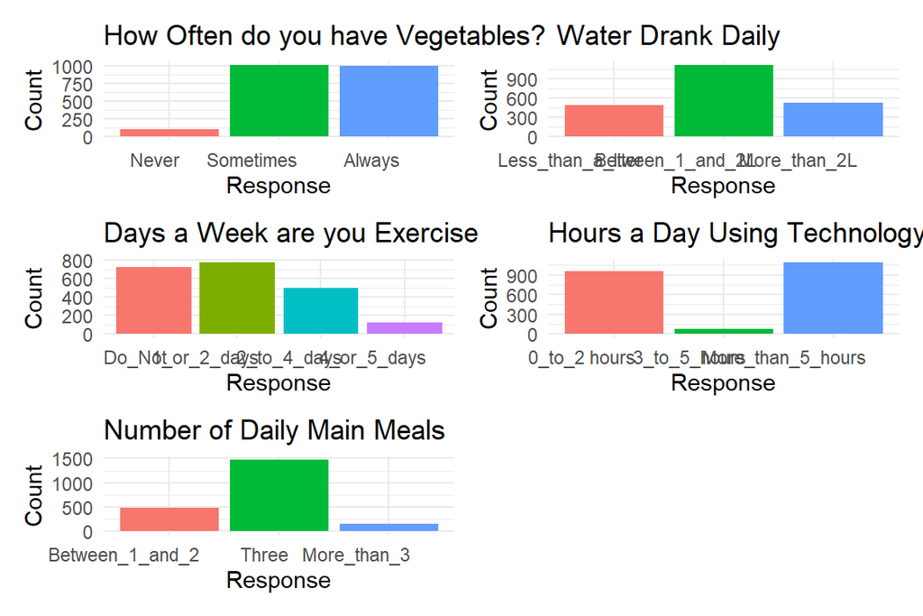

```r
t1 + t2 + t3 + t4 + t5 +
  plot_layout(ncol = 2)
```

For the categorical variables graphed above, none of them appear to be evenly distributed among the responses. Very few people responded that they never eat vegetables in their meals compared to the “Sometimes” and “Always” responses. Similarly fewer people were physically active 4 or 5 days a week compared to other response, and fewer people used technological devices 3 to 5 hours a day compared to other responses for that question. Most people ate three meals a day, while few ate more than 3 meals a day. Most people tended to drink between 1 and 2 litres of water of day. It is important to remember that the data was balanced for the weight categories, so these responses do not necessarily reflect the average responses of the population.

### 4.1 Weight Category as a Binary Variable

For this analysis I recoded the weight category variable into a binary variable of if the respondent was overweight or not. The overweight variable is 0 if the respondent’s weight category if “Insufficient Weight” or “Normal Weight”, and 1 else wise.

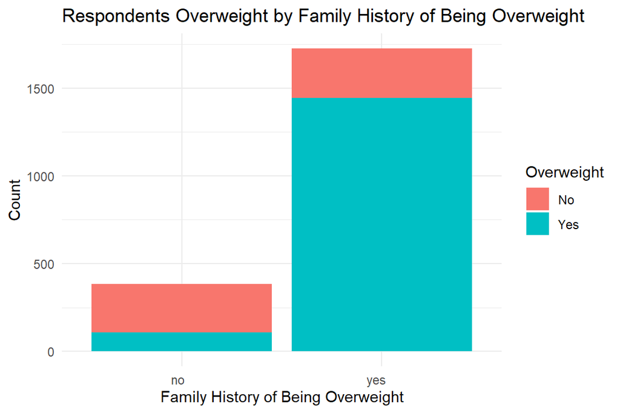

```r
obesity_mut %>%
  ggplot(aes( x=family_history_with_overweight, fill = overweight)) +
  geom_bar() +
  labs(title="Respondents Overweight by Family History of Being Overweight", x="Family History of Being Overweight", y="Count", fill="Overweight") +
  theme_minimal() +
   theme( axis.text.x = element_text(angle=0, vjust=.7, hjust=0.8))
```

The plot above shows that there are more respondents with a family history of being overweight and more respondents who are overweight. For respondents with a family history of being overweight, the majority of them are overweight themselves. Respondents who do not have a family history of being overweight appear to be more likely to not be overweight themselves.

## 5 Logistic Regression

### 5.1 Base Logistic Regression

```r
obesity_mut <- obesity_mut %>%
  mutate(overweight=ifelse(overweight=="Yes", 1, 0))
base.log = lm(overweight~family_history_with_overweight+FAVC, data=obesity_mut)
summary(base.log)
```

```
Call:
lm(formula = overweight ~ family_history_with_overweight + FAVC,
    data = obesity_mut)

Residuals:
    Min      1Q  Median      3Q     Max
-0.8514 -0.1533  0.1486  0.1486  0.8467

Coefficients:
                                  Estimate Std. Error t value Pr(>|t|)
(Intercept)                        0.15335    0.02767   5.543 3.35e-08 ***
family_history_with_overweightyes  0.53034    0.02198  24.129  < 2e-16 ***
FAVCyes                            0.16769    0.02650   6.328 3.02e-10 ***
---
Signif. codes:  0 '***' 0.001 '**' 0.01 '*' 0.05 '.' 0.1 ' ' 1

Residual standard error: 0.3814 on 2108 degrees of freedom
Multiple R-squared:  0.2538,    Adjusted R-squared:  0.253
F-statistic: 358.4 on 2 and 2108 DF,  p-value: < 2.2e-16
```

All variables in the baseline are significant with a family history of being overweight being a large predictor of being overweight. On average, having a family history of being overweight increases the likelihood of being overweight by 0.53034 controlling for if they eat high calorie foods or not.

### 5.2 Saturated Logistic Regression

```r
sat.log = lm(overweight~family_history_with_overweight + FAVC + FCVC.char + CH2O.char +          FAF.char + TUE.char + NCP.char + Age + Gender + SMOKE + SCC + CALC + MTRANS, data=obesity_mut)
summary(sat.log)
```

```
Call:
lm(formula = overweight ~ family_history_with_overweight + FAVC +
    FCVC.char + CH2O.char + FAF.char + TUE.char + NCP.char +
    Age + Gender + SMOKE + SCC + CALC + MTRANS, data = obesity_mut)

Residuals:
     Min       1Q   Median       3Q      Max
-1.16861 -0.12341  0.07292  0.19040  1.13797

Coefficients:
                                    Estimate Std. Error t value Pr(>|t|)
(Intercept)                       -0.9759705  0.3583311  -2.724  0.00651 **
family_history_with_overweightyes  0.4501029  0.0211902  21.241  < 2e-16 ***
FAVCyes                            0.1007321  0.0250836   4.016 6.13e-05 ***
FCVC.charSometimes                -0.0141005  0.0618674  -0.228  0.81973
FCVC.charAlways                   -0.0421984  0.0623018  -0.677  0.49828
CH2O.charBetween_1_and_2L          0.0209971  0.0193375   1.086  0.27768
CH2O.charMore_than_2L              0.0996226  0.0226398   4.400 1.14e-05 ***
FAF.char1_or_2_days               -0.0003841  0.0184788  -0.021  0.98342
FAF.char2_to_4_days               -0.0603305  0.0211899  -2.847  0.00445 **
FAF.char4_or_5_days               -0.0772665  0.0360952  -2.141  0.03242 *
TUE.char3_to_5_hours              -0.0687472  0.0735005  -0.935  0.34973
TUE.charMore_than_5_hours          0.0126886  0.0165318   0.768  0.44286
NCP.charThree                     -0.0795106  0.0185204  -4.293 1.84e-05 ***
NCP.charMore_than_3               -0.3025402  0.0338381  -8.941  < 2e-16 ***
Age                                0.0213927  0.0016441  13.012  < 2e-16 ***
GenderMale                         0.0508207  0.0167482   3.034  0.00244 **
SMOKEyes                          -0.1491109  0.0533937  -2.793  0.00528 **
SCCyes                             0.0054666  0.0377446   0.145  0.88486
CALCFrequently                     0.6717403  0.3498650   1.920  0.05499 .
CALCno                             0.6088078  0.3475817   1.752  0.08000 .
CALCSometimes                      0.7136442  0.3475791   2.053  0.04018 *
MTRANSBike                        -0.1062088  0.1326752  -0.801  0.42350
MTRANSMotorbike                   -0.0466357  0.1062643  -0.439  0.66080
MTRANSPublic_Transportation        0.1555593  0.0239748   6.488 1.08e-10 ***
MTRANSWalking                     -0.0941337  0.0522538  -1.801  0.07177 .
---
Signif. codes:  0 '***' 0.001 '**' 0.01 '*' 0.05 '.' 0.1 ' ' 1

Residual standard error: 0.3434 on 2086 degrees of freedom
Multiple R-squared:  0.4013,    Adjusted R-squared:  0.3944
F-statistic: 58.26 on 24 and 2086 DF,  p-value: < 2.2e-16
```

```r
vif(sat.log)
```

```
                                   GVIF Df GVIF^(1/(2*Df))
family_history_with_overweight 1.198289  1        1.094664
FAVC                           1.155178  1        1.074792
FCVC.char                      3.606921  2        1.378111
CH2O.char                      1.138096  2        1.032868
FAF.char                       1.297700  3        1.044389
TUE.char                       3.598843  2        1.377339
NCP.char                       1.212706  2        1.049395
Age                            1.947131  1        1.395396
Gender                         1.254828  1        1.120191
SMOKE                          1.041271  1        1.020427
SCC                            1.106742  1        1.052018
CALC                           1.208323  3        1.032041
MTRANS                         1.950802  4        1.087118
```

```r
#tue fcvc scc
step.log <- step(base.log, direction='both', scope=formula(sat.log), trace=0)
summary(step.log)
```

```
Call:
lm(formula = overweight ~ family_history_with_overweight + FAVC +
    Age + NCP.char + MTRANS + CALC + CH2O.char + Gender + FAF.char +
    SMOKE, data = obesity_mut)

Residuals:
     Min       1Q   Median       3Q      Max
-1.16685 -0.11991  0.07507  0.19167  1.13328

Coefficients:
                                    Estimate Std. Error t value Pr(>|t|)
(Intercept)                       -0.9831383  0.3529247  -2.786 0.005390 **
family_history_with_overweightyes  0.4514831  0.0209045  21.597  < 2e-16 ***
FAVCyes                            0.0998529  0.0247562   4.033 5.69e-05 ***
Age                                0.0211671  0.0015736  13.451  < 2e-16 ***
NCP.charThree                     -0.0795821  0.0184498  -4.313 1.68e-05 ***
NCP.charMore_than_3               -0.3069999  0.0337164  -9.105  < 2e-16 ***
MTRANSBike                        -0.1066408  0.1324811  -0.805 0.420940
MTRANSMotorbike                   -0.0588928  0.1059319  -0.556 0.578305
MTRANSPublic_Transportation        0.1537907  0.0239108   6.432 1.56e-10 ***
MTRANSWalking                     -0.0959794  0.0521937  -1.839 0.066071 .
CALCFrequently                     0.6607427  0.3497958   1.889 0.059038 .
CALCno                             0.5980695  0.3475013   1.721 0.085388 .
CALCSometimes                      0.6988574  0.3474638   2.011 0.044421 *
CH2O.charBetween_1_and_2L          0.0237639  0.0192675   1.233 0.217578
CH2O.charMore_than_2L              0.0995491  0.0224882   4.427 1.01e-05 ***
GenderMale                         0.0592790  0.0159278   3.722 0.000203 ***
FAF.char1_or_2_days                0.0002296  0.0184569   0.012 0.990074
FAF.char2_to_4_days               -0.0629024  0.0210514  -2.988 0.002840 **
FAF.char4_or_5_days               -0.0767627  0.0359647  -2.134 0.032927 *
SMOKEyes                          -0.1469745  0.0532862  -2.758 0.005863 **
---
Signif. codes:  0 '***' 0.001 '**' 0.01 '*' 0.05 '.' 0.1 ' ' 1

Residual standard error: 0.3434 on 2091 degrees of freedom
Multiple R-squared:  0.3999,    Adjusted R-squared:  0.3945
F-statistic: 73.34 on 19 and 2091 DF,  p-value: < 2.2e-16
```

```r
#no TUE or favc
vif(step.log)
```

```
                                   GVIF Df GVIF^(1/(2*Df))
family_history_with_overweight 1.166298  1        1.079953
FAVC                           1.125321  1        1.060812
Age                            1.783987  1        1.335660
NCP.char                       1.191119  2        1.044693
MTRANS                         1.919474  4        1.084920
CALC                           1.180320  3        1.028016
CH2O.char                      1.104710  2        1.025208
Gender                         1.135010  1        1.065369
FAF.char                       1.268125  3        1.040384
SMOKE                          1.037178  1        1.018419
```

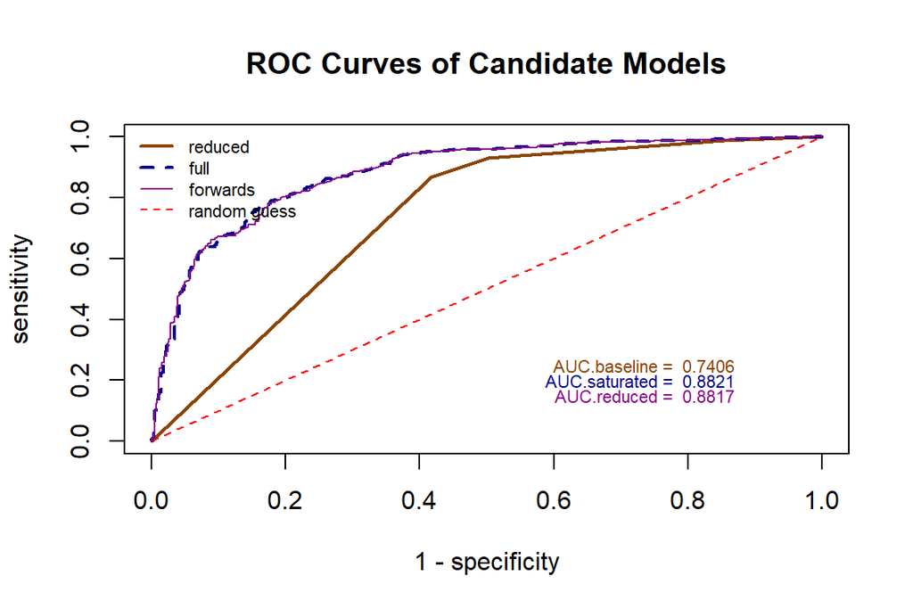

```r
## predict the "success" probabilities of each model based on the entire data set
preReduced = predict(base.log, newdata = obesity_mut,type="response" )
predfullModel = predict(sat.log, newdata = obesity_mut,type="response" )
predforwards = predict(step.log, newdata = obesity_mut,type="response" )
##
prediction.reduced = preReduced
prediction.full = predfullModel
prediction.forwards = predforwards
  category = obesity_mut$overweight == 1
  ROCobj.reduced <- roc(category, prediction.reduced)
  ROCobj.full <- roc(category, prediction.full)
  ROCobj.forwards <- roc(category, prediction.forwards)
## AUC
  reducedAUC = ROCobj.reduced$auc
  fullAUC = ROCobj.full$auc
  forwardsAUC = ROCobj.forwards$auc
## extract sensitivity and specificity from candidate models
  sen.reduced = ROCobj.reduced$sensitivities
  fnr.reduced = 1 - ROCobj.reduced$specificities
  #
  sen.full = ROCobj.full$sensitivities
  fnr.full = 1 - ROCobj.full$specificities
  #
  sen.forwards = ROCobj.forwards$sensitivities
  fnr.forwards = 1 - ROCobj.forwards$specificities
## Fond contrast color for ROC curves
  colors = c("#8B4500", "#00008B", "#8B008B")
## Plotting ROC curves
#par(type="s")
plot(fnr.reduced, sen.reduced, type = "l", lwd = 2, col = colors[1],
     xlim = c(0,1),
     ylim = c(0,1),
     xlab = "1 - specificity",
     ylab = "sensitivity",
     main = "ROC Curves of Candidate Models")
lines(fnr.full, sen.full, lwd = 2, lty = 2, col = colors[2])
lines(fnr.forwards, sen.forwards, lwd = 1, col = colors[3])
segments(0,0,1,1, lwd =1, col = "red", lty = 2)
legend("topleft", c("reduced", "full", "forwards", "random guess"),
       col=c(colors, "red"), lwd=c(2,2,1,1),
       lty=c(1,2,1,2), bty = "n", cex = 0.7)
## annotating AUC
text(0.87, 0.25, paste("AUC.baseline = ", round(reducedAUC,4)), col=colors[1], cex = 0.7, adj = 1)
text(0.87, 0.20, paste("AUC.saturated = ", round(fullAUC,4)), col=colors[2], cex = 0.7, adj = 1)
text(0.87, 0.15, paste("AUC.reduced = ", round(forwardsAUC,4)), col=colors[3], cex = 0.7, adj = 1)
```

```r
anova(step.log, sat.log)
```

```
Analysis of Variance Table

Model 1: overweight ~ family_history_with_overweight + FAVC + Age + NCP.char +
    MTRANS + CALC + CH2O.char + Gender + FAF.char + SMOKE
Model 2: overweight ~ family_history_with_overweight + FAVC + FCVC.char +
    CH2O.char + FAF.char + TUE.char + NCP.char + Age + Gender +
    SMOKE + SCC + CALC + MTRANS
  Res.Df    RSS Df Sum of Sq      F Pr(>F)
1   2091 246.62
2   2086 246.06  5   0.56711 0.9616   0.44
```

The saturated and reduced models performed about the same, and better than the baseline model. In terms of the AUC the reduced model would be the best model as it performed about the same as the saturated model, except with less variables in the model. Furthermore, a comparison between the saturated and reduced models shows that they are not significantly different in terms of model performance.

## 6 Single Layer Neural Network

```r
 fullModelNames=c("Gender", "Age", "family_history_with_overweight",
                  "FAVC", "CAEC", "SMOKE", "SCC", "CALC", "MTRANS", "FCVC.char",
                  "CH2O.char", "FAF.char", "TUE.char", "NCP.char", "overweight")
neuralData = obesity_mut[, fullModelNames]
## feature scaling
neuralData$Agescaled = (neuralData$Age-min(neuralData$Age))/(max(neuralData$Age) - min(neuralData$Age))


## drop original feature - keeping only features to be used in the neural network
ANNModelNames=c("Gender", "Agescaled", "family_history_with_overweight",
                "FAVC", "CAEC", "SMOKE", "SCC", "CALC", "MTRANS", "FCVC.char",
                 "CH2O.char", "FAF.char", "TUE.char", "NCP.char", "overweight")
## final data for the neuralnet() function
neuralDataFinal = neuralData[,ANNModelNames]





neuralModelFormula = model.matrix(~family_history_with_overweight + FAVC + FCVC.char + CH2O.char + FAF.char + TUE.char + NCP.char + Agescaled + Gender + SMOKE + SCC + CALC + MTRANS + overweight, data=neuralDataFinal)
# The following will list all numerical variables and automatically derived dummy variables

colnames(neuralModelFormula)
```

```
 [1] "(Intercept)"                       "family_history_with_overweightyes"
 [3] "FAVCyes"                           "FCVC.charSometimes"
 [5] "FCVC.charAlways"                   "CH2O.charBetween_1_and_2L"
 [7] "CH2O.charMore_than_2L"             "FAF.char1_or_2_days"
 [9] "FAF.char2_to_4_days"               "FAF.char4_or_5_days"
[11] "TUE.char3_to_5_hours"              "TUE.charMore_than_5_hours"
[13] "NCP.charThree"                     "NCP.charMore_than_3"
[15] "Agescaled"                         "GenderMale"
[17] "SMOKEyes"                          "SCCyes"
[19] "CALCFrequently"                    "CALCno"
[21] "CALCSometimes"                     "MTRANSBike"
[23] "MTRANSMotorbike"                   "MTRANSPublic_Transportation"
[25] "MTRANSWalking"                     "overweight"
```

```r
implicitFormulaDesignMatrix = model.matrix( ~., data = neuralDataFinal)
colnames(implicitFormulaDesignMatrix)
```

```
 [1] "(Intercept)"                       "GenderMale"
 [3] "Agescaled"                         "family_history_with_overweightyes"
 [5] "FAVCyes"                           "CAECFrequently"
 [7] "CAECno"                            "CAECSometimes"
 [9] "SMOKEyes"                          "SCCyes"
[11] "CALCFrequently"                    "CALCno"
[13] "CALCSometimes"                     "MTRANSBike"
[15] "MTRANSMotorbike"                   "MTRANSPublic_Transportation"
[17] "MTRANSWalking"                     "FCVC.charSometimes"
[19] "FCVC.charAlways"                   "CH2O.charBetween_1_and_2L"
[21] "CH2O.charMore_than_2L"             "FAF.char1_or_2_days"
[23] "FAF.char2_to_4_days"               "FAF.char4_or_5_days"
[25] "TUE.char3_to_5_hours"              "TUE.charMore_than_5_hours"
[27] "NCP.charThree"                     "NCP.charMore_than_3"
[29] "overweight"
```

```r
columnNames = colnames(implicitFormulaDesignMatrix)
columnList = paste(columnNames[-c(1,length(columnNames))], collapse = "+")
columnList = paste(c(columnNames[length(columnNames)],"~",columnList), collapse="")
modelFormula = formula(columnList)
modelFormula
```

```
overweight ~ GenderMale + Agescaled + family_history_with_overweightyes +
    FAVCyes + CAECFrequently + CAECno + CAECSometimes + SMOKEyes +
    SCCyes + CALCFrequently + CALCno + CALCSometimes + MTRANSBike +
    MTRANSMotorbike + MTRANSPublic_Transportation + MTRANSWalking +
    FCVC.charSometimes + FCVC.charAlways + CH2O.charBetween_1_and_2L +
    CH2O.charMore_than_2L + FAF.char1_or_2_days + FAF.char2_to_4_days +
    FAF.char4_or_5_days + TUE.char3_to_5_hours + TUE.charMore_than_5_hours +
    NCP.charThree + NCP.charMore_than_3
```

```r
#step function, and ReLU function
NetworkModel = neuralnet(modelFormula,
                         data = implicitFormulaDesignMatrix,  # must be the design matrix
                         hidden = 1,
                         act.fct = "logistic",     # sigmoid activation function
                         linear.output = FALSE
                         )
kable(NetworkModel$result.matrix)
```

| error | 84.0270715 |
| --- | --- |
| reached.threshold | 0.0099735 |
| steps | 4395.0000000 |
| Intercept.to.1layhid1 | -9.7285368 |
| GenderMale.to.1layhid1 | 0.5940135 |
| Agescaled.to.1layhid1 | 19.3026693 |
| family_history_with_overweightyes.to.1layhid1 | 3.9792580 |
| FAVCyes.to.1layhid1 | 0.5144872 |
| CAECFrequently.to.1layhid1 | -1.9976161 |
| CAECno.to.1layhid1 | 5.0617676 |
| CAECSometimes.to.1layhid1 | 3.4855663 |
| SMOKEyes.to.1layhid1 | -3.2119203 |
| SCCyes.to.1layhid1 | 2.4063213 |
| CALCFrequently.to.1layhid1 | 1.0866917 |
| CALCno.to.1layhid1 | -1.6298627 |
| CALCSometimes.to.1layhid1 | -1.0112497 |
| MTRANSBike.to.1layhid1 | -5.7692431 |
| MTRANSMotorbike.to.1layhid1 | 1.4912983 |
| MTRANSPublic_Transportation.to.1layhid1 | 2.6748223 |
| MTRANSWalking.to.1layhid1 | 0.3665207 |
| FCVC.charSometimes.to.1layhid1 | 0.8356262 |
| FCVC.charAlways.to.1layhid1 | 0.3565515 |
| CH2O.charBetween_1_and_2L.to.1layhid1 | -0.0262491 |
| CH2O.charMore_than_2L.to.1layhid1 | -0.0933600 |
| FAF.char1_or_2_days.to.1layhid1 | 0.4366374 |
| FAF.char2_to_4_days.to.1layhid1 | -0.2022964 |
| FAF.char4_or_5_days.to.1layhid1 | -1.1578623 |
| TUE.char3_to_5_hours.to.1layhid1 | -1.0384277 |
| TUE.charMore_than_5_hours.to.1layhid1 | 0.0004807 |
| NCP.charThree.to.1layhid1 | -0.5401963 |
| NCP.charMore_than_3.to.1layhid1 | -2.6792430 |
| Intercept.to.overweight | -2.5996884 |
| 1layhid1.to.overweight | 5.5374363 |

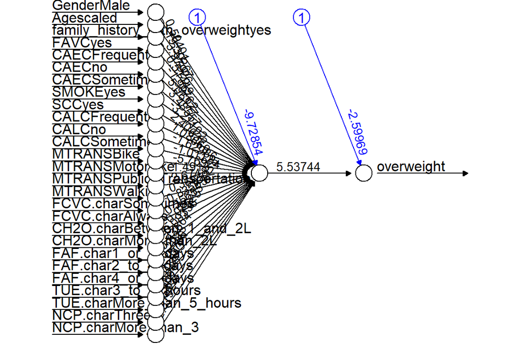

```r
plot(NetworkModel, rep="best")
```

```r
tanNetworkModel = neuralnet(modelFormula,
                         data = implicitFormulaDesignMatrix,  # must be the design matrix
                         hidden = 1,
                         act.fct = "tanh",     # tan activation function
                         linear.output = FALSE
                         )
kable(tanNetworkModel$result.matrix)
```

| error | 95.3492989 |
| --- | --- |
| reached.threshold | 0.0098161 |
| steps | 27980.0000000 |
| Intercept.to.1layhid1 | 23.1748399 |
| GenderMale.to.1layhid1 | 7.5752026 |
| Agescaled.to.1layhid1 | -123.8888165 |
| family_history_with_overweightyes.to.1layhid1 | -22.2394832 |
| FAVCyes.to.1layhid1 | 5.5466849 |
| CAECFrequently.to.1layhid1 | 40.1310491 |
| CAECno.to.1layhid1 | -25.0545105 |
| CAECSometimes.to.1layhid1 | -14.7645859 |
| SMOKEyes.to.1layhid1 | -56.5107222 |
| SCCyes.to.1layhid1 | -16.7997974 |
| CALCFrequently.to.1layhid1 | -79.0593078 |
| CALCno.to.1layhid1 | 4.8762507 |
| CALCSometimes.to.1layhid1 | 9.2630107 |
| MTRANSBike.to.1layhid1 | 39.4869782 |
| MTRANSMotorbike.to.1layhid1 | 28.9375146 |
| MTRANSPublic_Transportation.to.1layhid1 | -14.5873884 |
| MTRANSWalking.to.1layhid1 | -3.3183138 |
| FCVC.charSometimes.to.1layhid1 | 1.1528943 |
| FCVC.charAlways.to.1layhid1 | 4.5586467 |
| CH2O.charBetween_1_and_2L.to.1layhid1 | 5.1753782 |
| CH2O.charMore_than_2L.to.1layhid1 | 8.1075834 |
| FAF.char1_or_2_days.to.1layhid1 | -2.0059420 |
| FAF.char2_to_4_days.to.1layhid1 | -6.5111586 |
| FAF.char4_or_5_days.to.1layhid1 | 3.5015972 |
| TUE.char3_to_5_hours.to.1layhid1 | -114.8270523 |
| TUE.charMore_than_5_hours.to.1layhid1 | 7.7566168 |
| NCP.charThree.to.1layhid1 | 5.1407641 |
| NCP.charMore_than_3.to.1layhid1 | 16.8832400 |
| Intercept.to.overweight | 0.8065907 |
| 1layhid1.to.overweight | -0.7000771 |

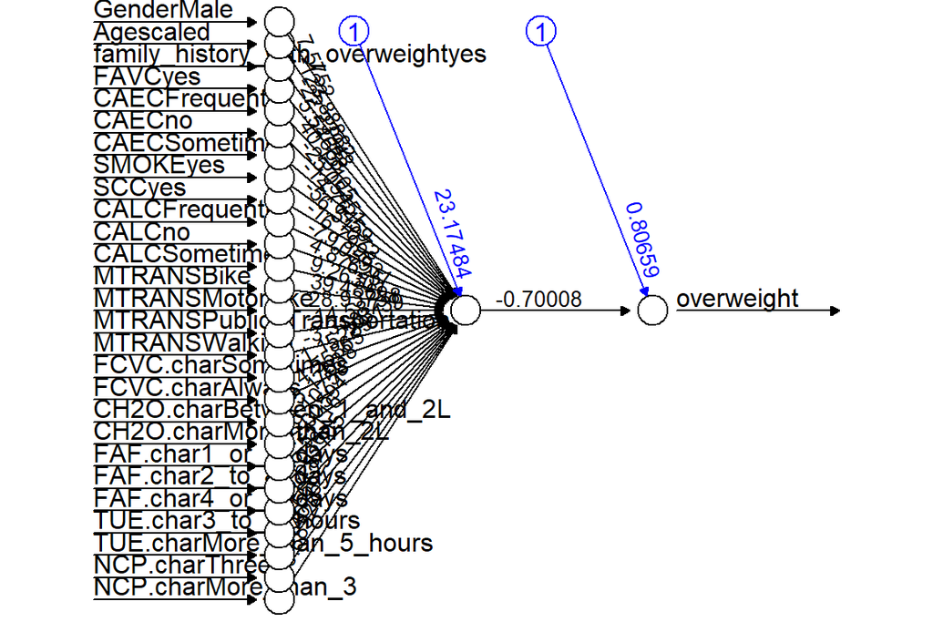

```r
plot(tanNetworkModel, rep="best")
```

### 6.1 AUC Curves of Logistic Regressions and Neural Network Models

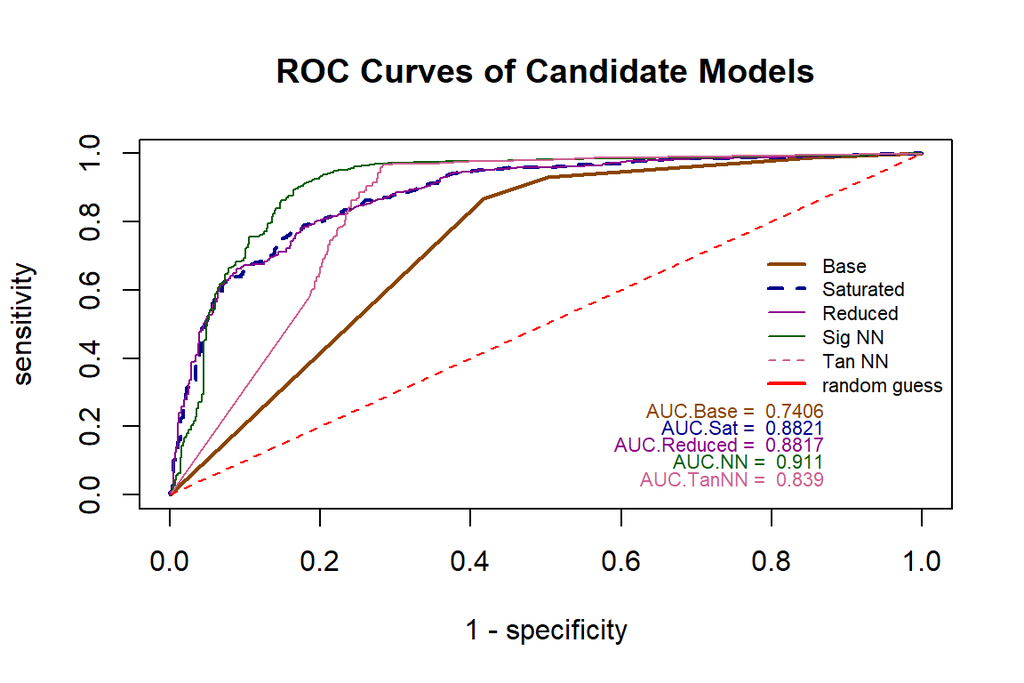

```r
predNN = predict(NetworkModel, newdata = implicitFormulaDesignMatrix, linear.output = FALSE)
tanpredNN = predict(tanNetworkModel, newdata = implicitFormulaDesignMatrix, linear.output = FALSE)
preReduced = predict(base.log, newdata = obesity_mut,type="response" )
predfullModel = predict(sat.log, newdata = obesity_mut,type="response" )
predforwards = predict(step.log, newdata = obesity_mut,type="response" )
##
##
prediction.reduced = preReduced
prediction.full = predfullModel
prediction.forwards = predforwards
  category = obesity_mut$overweight == 1
  ROCobj.reduced <- roc(category, prediction.reduced)
  ROCobj.full <- roc(category, prediction.full)
  ROCobj.forwards <- roc(category, prediction.forwards)
  ROCobj.NN <-roc(category, predNN)
  ROCobj.tanNN <-roc(category, tanpredNN)
## AUC
  reducedAUC = ROCobj.reduced$auc
  fullAUC = ROCobj.full$auc
  forwardsAUC = ROCobj.forwards$auc
  NNAUC = ROCobj.NN$auc
  tanNNAUC = ROCobj.tanNN$auc
## extract sensitivity and specificity from candidate models
  sen.reduced = ROCobj.reduced$sensitivities
  fnr.reduced = 1 - ROCobj.reduced$specificities
  #
  sen.full = ROCobj.full$sensitivities
  fnr.full = 1 - ROCobj.full$specificities
  #
  sen.forwards = ROCobj.forwards$sensitivities
  fnr.forwards = 1 - ROCobj.forwards$specificities
  #
  sen.NN = ROCobj.NN$sensitivities
  fnr.NN = 1 - ROCobj.NN$specificities
  #
  sen.tanNN = ROCobj.tanNN$sensitivities
  fnr.tanNN = 1 - ROCobj.tanNN$specificities

## Fond contrast color for ROC curves
  colors = c("#8B4500", "#00008B", "#8B008B", "#055d03", "hotpink3")
## Plotting ROC curves
#par(type="s")
plot(fnr.reduced, sen.reduced, type = "l", lwd = 2, col = colors[1],
     xlim = c(0,1),
     ylim = c(0,1),
     xlab = "1 - specificity",
     ylab = "sensitivity",
     main = "ROC Curves of Candidate Models")
lines(fnr.full, sen.full, lwd = 2, lty = 2, col = colors[2])
lines(fnr.forwards, sen.forwards, lwd = 1, col = colors[3])
lines(fnr.NN, sen.NN, lwd = 1, col = colors[4])
lines(fnr.tanNN, sen.tanNN, lwd = 1, col = colors[5])

segments(0,0,1,1, lwd =1, col = "red", lty = 2)
legend("right", c("Base", "Saturated", "Reduced", "Sig NN", "Tan NN", "random guess"),
       col=c(colors, "red"), lwd=c(2,2,1,1,1),
       lty=c(1,2,1,1,2), bty = "n", cex = 0.7)
## annotating AUC
text(0.87, 0.25, paste("AUC.Base = ", round(reducedAUC,4)), col=colors[1], cex = 0.7, adj = 1)
text(0.87, 0.20, paste("AUC.Sat = ", round(fullAUC,4)), col=colors[2], cex = 0.7, adj = 1)
text(0.87, 0.15, paste("AUC.Reduced = ", round(forwardsAUC,4)), col=colors[3], cex = 0.7, adj = 1)
text(0.87, 0.10, paste("AUC.NN = ", round(NNAUC,4)), col=colors[4], cex = 0.7, adj = 1)
text(0.87, 0.05, paste("AUC.TanNN = ", round(tanNNAUC,4)), col=colors[5], cex = 0.7, adj = 1)
```

## 7 Decision Tree

```r
n = dim(obesity_mut)[1]  # sample size
# caution: using without replacement
#use 0.68 to get training dataset that is multiple of 5
train.id = sample(1:n, round(0.68*n), replace = FALSE)
train = obesity_mut[train.id, ]    # training data
test = obesity_mut[-train.id, ]    # testing data
```

```r
# arguments to pass into rpart():
# 1. data set (training /testing);
# 2. Penalty coefficients
# 3. Impurity measure
##
tree.builder = function(in.data, fp, fn, purity){
   tree = rpart(overweight ~ family_history_with_overweight + FAVC + FCVC.char + CH2O.char +          FAF.char + TUE.char + NCP.char + Age + Gender + SMOKE + SCC + CALC + MTRANS,                # including all features
                data = in.data,
                na.action  = na.rpart,       # By default, deleted if the outcome is missing,
                                             # kept if predictors are missing
                method = "class",            # Classification form factor
                model  = FALSE,
                x = FALSE,
                y = TRUE,
            parms = list( # loss matrix. Penalize false positives or negatives more heavily
                         loss = matrix(c(0, fp, fn, 0), ncol = 2, byrow = TRUE),
                         split = purity),          # "gini" or "information"
             ## rpart algorithm options (These are defaults)
             control = rpart.control(
                        minsplit = 10,  # minimum number of observations required before split
                        minbucket= 10,  # minimum number of observations in
                                        # any terminal node, default = minsplit/3
                        cp  = 0.01,  # complexity parameter for stopping rule,
                                     # 0.02 -> small tree
                       xval = 10     # number of cross-validation )
                        )
             )
  }
```

### 7.1 Decision Trees

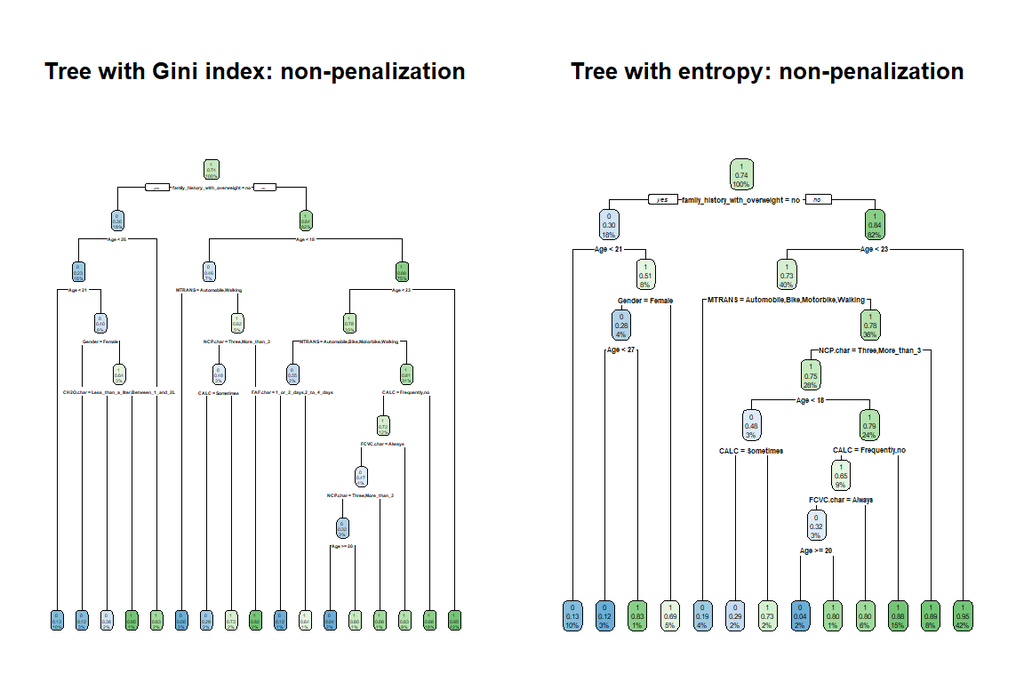

```r
#false positive saying you have you it when you dont
#saying you donet have it when you do
#balance
gini.tree.1.1 = tree.builder(in.data = train, fp = 1, fn = 1, purity = "gini")
info.tree.1.1 = tree.builder(in.data = train, fp = 1, fn = 1, purity = "information")
#penalize false positive
gini.tree.10.1 = tree.builder(in.data = train, fp = 10, fn = 1, purity = "gini")
info.tree.10.1 = tree.builder(in.data = train, fp = 10, fn = 1, purity = "information")
#penalize false negative
gini.tree.1.10 = tree.builder(in.data = train, fp = 1, fn = 10, purity = "gini")
info.tree.1.10 = tree.builder(in.data = train, fp = 1, fn = 10, purity = "information")

## tree plots
par(mfrow=c(1,2))
rpart.plot(gini.tree.1.1, main = "Tree with Gini index: non-penalization")
rpart.plot(info.tree.1.1, main = "Tree with entropy: non-penalization")
```

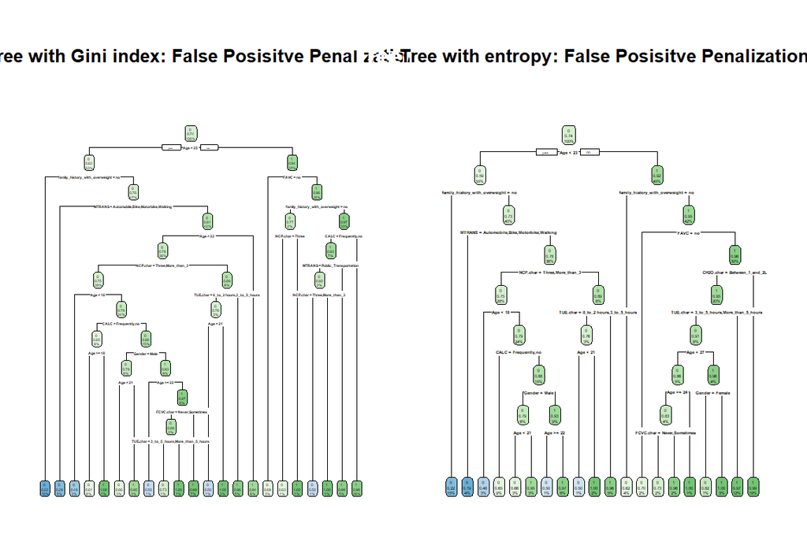

```r
par(mfrow=c(1,2))
rpart.plot(gini.tree.10.1, main = "Tree with Gini index: False Posisitve Penalization")
rpart.plot(info.tree.10.1, main = "Tree with entropy: False Posisitve Penalization")
```

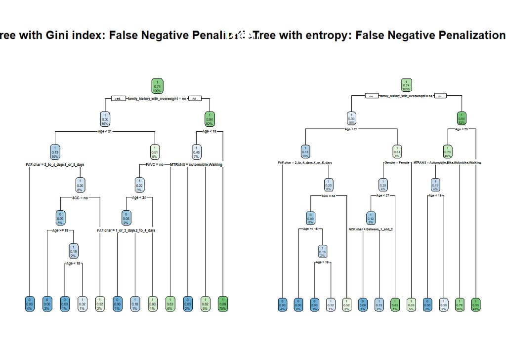

```r
par(mfrow=c(1,2))
rpart.plot(gini.tree.1.10, main = "Tree with Gini index: False Negative Penalization")
rpart.plot(info.tree.1.10, main = "Tree with entropy: False Negative Penalization")
```

```r
# function returning a sensitivity and specificity matrix
SenSpe = function(in.data, fp, fn, purity){
  cutoff = seq(0,1, length = 20)   # 20 cut-offs including 0 and 1.
  model = tree.builder(in.data, fp, fn, purity)
  ## Caution: decision tree returns both "success" and "failure" probabilities.
  ## We need only "success" probability to define sensitivity and specificity!!!
  pred = predict(model, newdata = in.data, type = "prob") # two-column matrix.
  senspe.mtx = matrix(0, ncol = length(cutoff), nrow= 2, byrow = FALSE)
  for (i in 1:length(cutoff)){
  # CAUTION: "pos" and "neg" are values of the label in this data set!
  # The following line uses only "pos" probability: pred[, "pos"] !!!!
  pred.out =  ifelse(pred[,1] >= cutoff[i], 1, 0)
  TP = sum(pred.out ==1 & in.data$overweight == 1)
  TN = sum(pred.out ==0 & in.data$overweight == 0)
  FP = sum(pred.out ==1 & in.data$overweight == 0)
  FN = sum(pred.out ==0 & in.data$overweight == 1)
  senspe.mtx[1,i] = TP/(TP + FN)
  senspe.mtx[2,i] = TN/(TN + FP)
  }
  ## A better approx of ROC, need library {pROC}
  prediction = pred[,1]
  category = in.data$overweight == 1
  ROCobj <- roc(category, prediction)
  AUC = auc(ROCobj)
  ##
  list(senspe.mtx= senspe.mtx, AUC = round(AUC,3))
}
```

```r
giniROC11 = SenSpe(in.data = test, fp=1, fn=1, purity="gini")
infoROC11 = SenSpe(in.data = test, fp=1, fn=1, purity="information")
giniROC110 = SenSpe(in.data = test, fp=1, fn=10, purity="gini")
infoROC110 = SenSpe(in.data = test, fp=1, fn=10, purity="information")
giniROC101 = SenSpe(in.data = test, fp=10, fn=1, purity="gini")
infoROC101 = SenSpe(in.data = test, fp=10, fn=1, purity="information")
```